# Calibration, equifinality

# Models and Parameters

Things we’ve covered

- **Sensitivity Analysis**
  - what are the most important parameters to get ‘right’
  - what drives your system
    - can be quantified by Sobel Indices, PRCC or just graphed
- **Performance Evaluation**
  - how does the model perform relative to observations
  - how do different parameters influence performance
    - can be quantified by metrics tailored to response of interest
- **Calibration**
  - use model performance to decide which parameters are acceptable (given uncertainty in those parameters)
- **Optimization**
  - a way to find the ‘best’ parameter by efficiently searching the parameter space

For most of these how you search parameter space matters - we’ve covered Sobel (a variance based method) and Latin Hypercube as a way to do this

# Background material

See materials in choosingmodels.pdf

# Calibration

Calibration is picking parameter sets based on performance evaluation

Apply metrics over multiple outputs (generated by running across many parameters sets) - like we’ve done in our sensitivity analysis work

Example - a dataset where each column is a different model run for Sagehen Creek (using different parameters) - don’t worry about the parameters for now

- sagerm.txt

```r
source("../R/nse.R")
# original data set - a single streamflow and observed data
sager = read.table("../Data/sager.txt", header=T)
head(sager)
```

```
##       model       obs month day year   wy wyd
## 1 0.4238063 0.3358678    10   1 1965 1966   1
## 2 0.4133587 0.3208737    10   2 1965 1966   2
## 3 0.4032640 0.3058796    10   3 1965 1966   3
## 4 0.3935287 0.2968832    10   4 1965 1966   4
## 5 0.3841480 0.2968832    10   5 1965 1966   5
## 6 0.3751000 0.2968832    10   6 1965 1966   6
```

```r
# add date
sager = sager %>% mutate(date = paste(day,month,year, sep="/"))
sager$date = as.Date(sager$date,"%d/%m/%Y")

# multiple results - lets say we've run the model for multiple years, each column
# is streamflow for a different parameter set
msage = read.table("../Data/sagerm.txt", header=T)

# lets say we know the start date from our earlier output
msage$date = sager$date
head(msage)
```

```
##        V99.1    V100.1       V101      V102       V103      V104      V105
## 1 0.07191767 0.3316747 0.04331200 0.1875757 0.07469700 0.2454343 0.1347037
## 2 0.06689267 0.3179167 0.04020500 0.1819137 0.06790767 0.2412470 0.1286780
## 3 0.06221900 0.3047440 0.03732067 0.1764227 0.06173567 0.2371983 0.1229220
## 4 0.05787167 0.2921237 0.03464333 0.1710973 0.05612433 0.2332663 0.1174237
## 5 0.05382833 0.2800427 0.03215800 0.1659330 0.05102333 0.2294617 0.1121710
## 6 0.05006733 0.2684613 0.02985100 0.1609243 0.04638600 0.2257630 0.1071530
##           V106      V107        V108      V109      V110       V111        V112
## 1 0.0003533333 0.2383413 0.003331333 0.2431933 0.3644930 0.05328633 0.005250000
## 2 0.0003400000 0.2321840 0.003039333 0.2355610 0.3583200 0.05014967 0.004755333
## 3 0.0003273333 0.2261857 0.002773000 0.2281683 0.3522187 0.04719767 0.004307333
## 4 0.0003150000 0.2203423 0.002530000 0.2210077 0.3463190 0.04441933 0.003901333
## 5 0.0003033333 0.2146500 0.002308333 0.2140717 0.3404873 0.04180433 0.003533667
## 6 0.0002920000 0.2091047 0.002106333 0.2073533 0.3347960 0.03934333 0.003200667
##        V113        V114      V115       V116       V117      V118      V119
```

[output cut: 90 more lines]

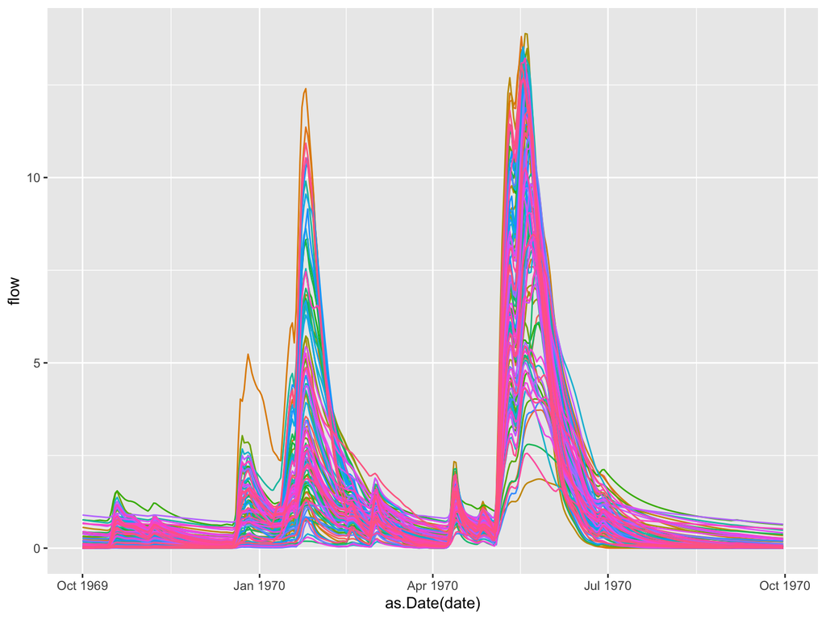

```r
msage$month = sager$month
msage$year = sager$year
msage$day = sager$day
msage$wy = sager$wy

# and we still have observed data from above


# how can we plot all results - lets plot water year 1970 otherwise its hard to see
msagel = msage %>% pivot_longer(cols=!c(date, month, year, day,wy), names_to="run", values_to="flow")

p1=ggplot(subset(msagel, wy == 1970), aes(as.Date(date), flow, col=run))+geom_line()+theme(legend.position = "none")
p1
```

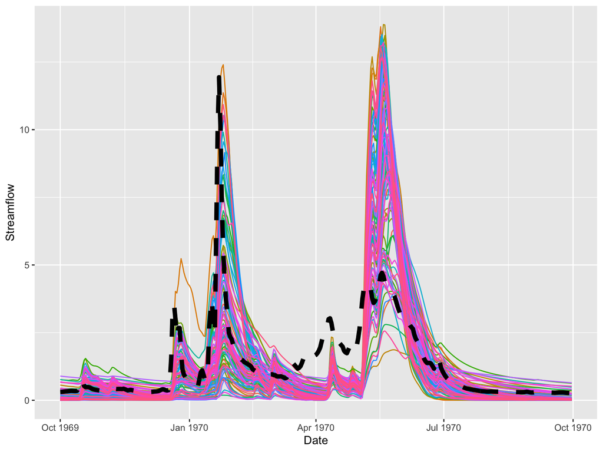

```r
# lets add observed streamflow
p1+geom_line(data=subset(sager, wy == 1970), aes(as.Date(date), obs), size=2, col="black", linetype=2)+labs(y="Streamflow", x="Date")
```

```r
# compute performance measures for all output
res = msage %>% select(!c("date","month","year","day","wy")) %>%
      map_dbl(nse, o=sager$obs )

head(res)
```

```
##      V99.1     V100.1       V101       V102       V103       V104
## -0.5443680  0.4855281  0.2654724  0.2178853  0.2715622  0.5031371
```

```r
# another example using our low flow statistics
# use apply to compute for all the data
source("../R/compute_lowflowmetrics_all.R")
res = msage %>% select(-date, -month, -day, -year, -wy ) %>% map_df(compute_lowflowmetrics_all, o=sager$obs, month=msage$month, day=msage$day, year=msage$year, wy=msage$wy)
# interesting to look at range of metrics - could use this to decide on
# acceptable values
summary(res)
```

```
##  annual_min_err    annual_min_cor   low_month_err    low_month_cor
##  Min.   :-0.2036   Min.   :0.4350   Min.   :-9.857   Min.   :0.1076
##  1st Qu.:-0.1977   1st Qu.:0.5760   1st Qu.:-7.899   1st Qu.:0.2050
##  Median :-0.1853   Median :0.6034   Median :-6.044   Median :0.5889
##  Mean   :-0.1526   Mean   :0.6296   Mean   :-4.434   Mean   :0.5211
##  3rd Qu.:-0.1471   3rd Qu.:0.7315   3rd Qu.:-3.183   3rd Qu.:0.7762
##  Max.   : 0.2004   Max.   :0.8192   Max.   :13.004   Max.   :0.8774
##     combined
##  Min.   :0.1402
##  1st Qu.:0.1957
##  Median :0.3161
##  Mean   :0.3297
##  3rd Qu.:0.4033
##  Max.   :0.6522
```

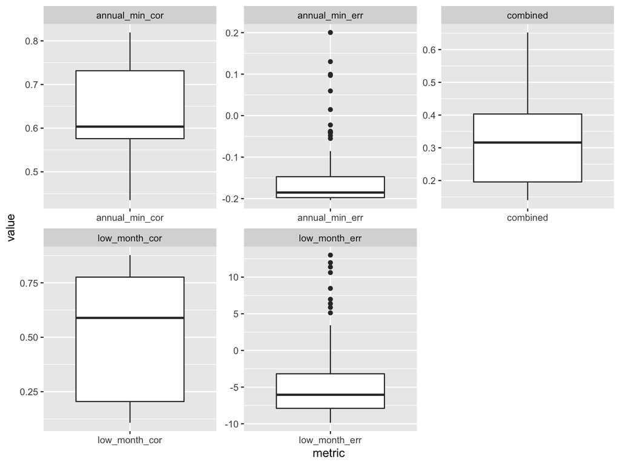

```r
# graph range of performance measures
resl = res %>% pivot_longer(cols=everything(), names_to="metric", values_to="value")
ggplot(resl, aes(metric, value))+geom_boxplot()+facet_wrap(~metric, scales="free")
```

```r
# try this
# assign an identifier to each row, use the same identify for columns of original streamflow data
# we can then use that to pick data
res$run = seq(from=1,to=nrow(res))
head(msage)
```

```
##        V99.1    V100.1       V101      V102       V103      V104      V105
## 1 0.07191767 0.3316747 0.04331200 0.1875757 0.07469700 0.2454343 0.1347037
## 2 0.06689267 0.3179167 0.04020500 0.1819137 0.06790767 0.2412470 0.1286780
## 3 0.06221900 0.3047440 0.03732067 0.1764227 0.06173567 0.2371983 0.1229220
## 4 0.05787167 0.2921237 0.03464333 0.1710973 0.05612433 0.2332663 0.1174237
## 5 0.05382833 0.2800427 0.03215800 0.1659330 0.05102333 0.2294617 0.1121710
## 6 0.05006733 0.2684613 0.02985100 0.1609243 0.04638600 0.2257630 0.1071530
##           V106      V107        V108      V109      V110       V111        V112
## 1 0.0003533333 0.2383413 0.003331333 0.2431933 0.3644930 0.05328633 0.005250000
## 2 0.0003400000 0.2321840 0.003039333 0.2355610 0.3583200 0.05014967 0.004755333
## 3 0.0003273333 0.2261857 0.002773000 0.2281683 0.3522187 0.04719767 0.004307333
## 4 0.0003150000 0.2203423 0.002530000 0.2210077 0.3463190 0.04441933 0.003901333
## 5 0.0003033333 0.2146500 0.002308333 0.2140717 0.3404873 0.04180433 0.003533667
## 6 0.0002920000 0.2091047 0.002106333 0.2073533 0.3347960 0.03934333 0.003200667
##        V113        V114      V115       V116       V117      V118      V119
```

[output cut: 90 more lines]

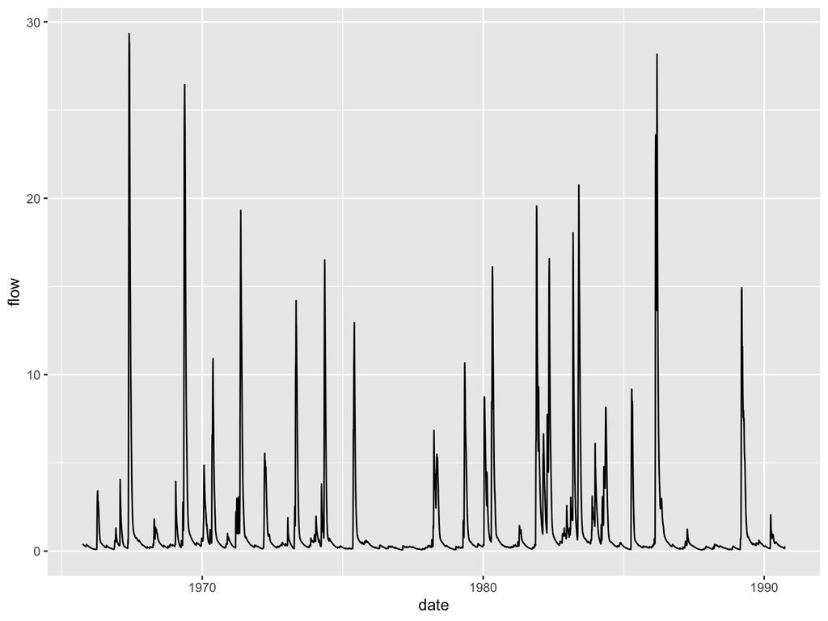

```r
colnames(msage)=c(res$run, "date","month","year","day","wy")

# best one
best = res[which.max(res$combined),]
msagel  =  msage %>% pivot_longer(cols=!c(date, month, year, day,wy), names_to="run", values_to="flow")
ggplot(subset(msagel, run == best$run), aes(date, flow)) + geom_line()
```

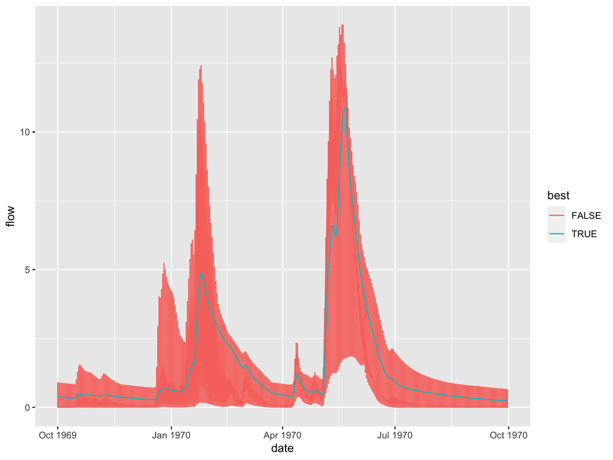

```r
# or show with all runs
# label runs for legends
# all just show 1970 so easy to see
msagel = msagel %>% mutate(best = ifelse(run==best$run, TRUE, FALSE))
ggplot(subset(msagel, wy==1970), aes(date, flow, col=best))+geom_line()
```

# Glue - generalized uncertainty analysis

What if we wanted to keep all of the ‘good’ parameters

- we could just keep them all as equally likely
- we could weight them by performance

Either way we can graph and come up with ‘best’ prediction accounting for uncertainty

Create a single measure of accuracy - above we used *compute_lowlowmetrics_all* to compute an accuracy measure based on

- relative error in annual minimum flow estimate
- relative error in monthly flow during low flow period
- correlation between observed and modelled annual minimum flow
- correlation between observed and modelled flow during the low flow period

We weighted all 4 the same

# Use the accuracy measure

We can use the combined accuacy measure to define behavioural (acceptible) parameter set (**res_acc**) - two options

- define a threshold (we will use 30%)
- take top 50 performing parameter sets

(we go with the latter but code could be commented to go with threshold approach)

```
##    Min. 1st Qu.  Median    Mean 3rd Qu.    Max.
##  0.1402  0.1957  0.3161  0.3297  0.4033  0.6522
```

```
## # A tibble: 6 × 6
##   annual_min_err annual_min_cor low_month_err low_month_cor combined   run
##            <dbl>          <dbl>         <dbl>         <dbl>    <dbl> <int>
## 1        -0.155           0.594         -1.68         0.643    0.474     2
## 2        -0.165           0.618         -5.23         0.724    0.335     4
## 3        -0.0978          0.799         -1.90         0.815    0.567     6
## 4        -0.147           0.670         -3.67         0.754    0.420     9
## 5        -0.156           0.608         -3.94         0.713    0.381    11
## 6        -0.0855          0.752          2.23         0.799    0.565    12
```

```
## # A tibble: 6 × 6
##   annual_min_err annual_min_cor low_month_err low_month_cor combined   run
##            <dbl>          <dbl>         <dbl>         <dbl>    <dbl> <int>
## 1        -0.0550          0.755          1.98         0.795    0.652    84
## 2        -0.0376          0.810          3.32         0.825    0.648    29
## 3        -0.0416          0.819          3.44         0.865    0.645    40
## 4         0.0147          0.784          8.46         0.859    0.625    15
## 5        -0.0481          0.753          2.90         0.800    0.623    20
## 6        -0.112           0.773         -1.45         0.877    0.589    68
```

# Defining weights (likelihood) for parameter sets

Now define “weights” (likelihood) based on parameter performance for the acceptable or behaviorial parameters

We want the sum of the weights to equal 1

- accuracy measure defined above will define weight
- we normalize by the range of accuracy for the behavioural parameters
- this **relative accuracy** becomes the weight
- note we now only work with behavioural parameter sets (in ** res_acc ** versus ** res **)

```
##    Min. 1st Qu.  Median    Mean 3rd Qu.    Max.
## 0.01423 0.01703 0.01813 0.02000 0.02376 0.02902
```

```
## [1] 1
```

```
## [1] 50
```

# Using weights

One way to use weights is to define a maximum likelihood estimate by averaging (weighted by accuracy) streamflow from all behavioural simulations

```
## # A tibble: 6 × 15
##   date       month  year   day    wy   run  flow best  annual_min_err
##   <date>     <int> <int> <int> <int> <dbl> <dbl> <lgl>          <dbl>
## 1 1965-10-01    10  1965     1  1966     2 0.332 FALSE        -0.155
## 2 1965-10-01    10  1965     1  1966     4 0.188 FALSE        -0.165
## 3 1965-10-01    10  1965     1  1966     6 0.245 FALSE        -0.0978
## 4 1965-10-01    10  1965     1  1966     9 0.238 FALSE        -0.147
## 5 1965-10-01    10  1965     1  1966    11 0.243 FALSE        -0.156
## 6 1965-10-01    10  1965     1  1966    12 0.364 FALSE        -0.0855
## # … with 6 more variables: annual_min_cor <dbl>, low_month_err <dbl>,
## #   low_month_cor <dbl>, combined <dbl>, w_acc <dbl>, wt_acc <dbl>
```

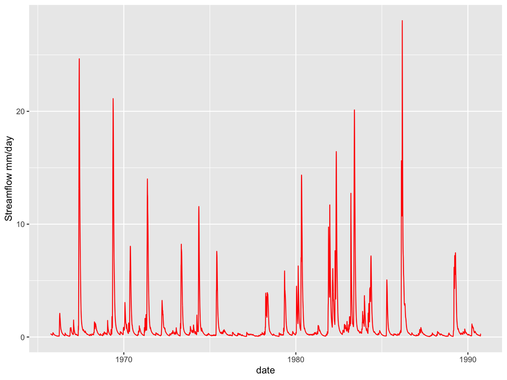

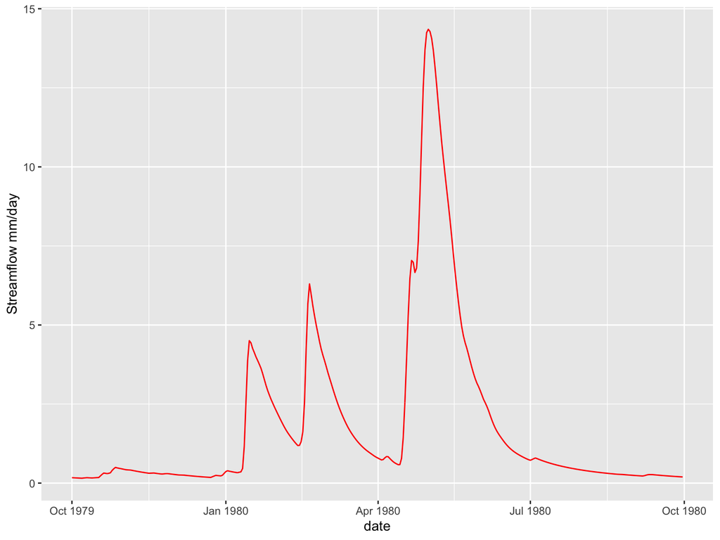

We could also compute quantiles rather than just mean

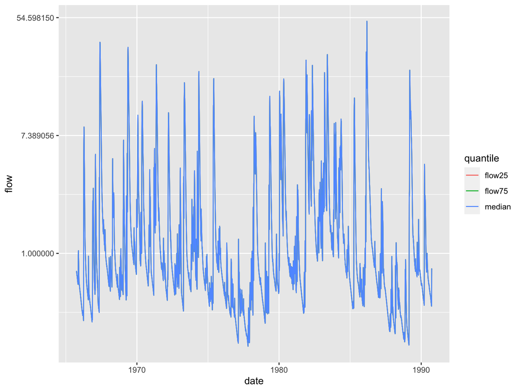

```r
# compute quantiles using weighted quantile
aver_flow = msagel_acc %>% group_by(date) %>% dplyr::summarize(
median = wtd.quantile(flow, probs=c(0.5), weights=wt_acc),
flow25 = wtd.quantile(flow,probs=c(0.25), weights=wt_acc), flow75=wtd.quantile(flow, probs=c(0.75), weights=wt_acc))

# format for plotting
aver_flowl = aver_flow %>% pivot_longer(col=c(-date), values_to="flow", names_to="quantile")

ggplot(subset(aver_flowl, wy=1980), aes(date, flow, col=quantile))+geom_line()+scale_y_continuous(trans="log")
```

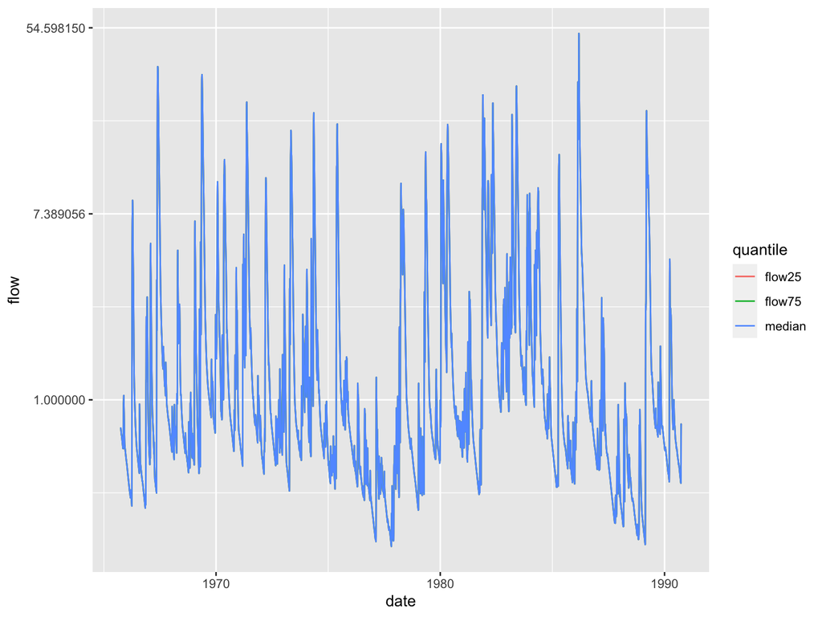

```r
# to see low flows, transform y-axis
ggplot(subset(aver_flowl, wy=1980), aes(date, flow, col=quantile))+geom_line()+scale_y_continuous(trans="log")
```